# t-SNE for High-Dimensional data visualization in R

t-SNE is dimensionality reduction technique suitable for visualizing high dimensional datasets. tSNE is an abbreviation of t-Distributed Stochastic Neighbor Embedding (t-SNE) and it was introduced by van der Maaten and Hinton.

We won’t go through the specific theoretical underpinnings of this method, but if you want a simple yet complete explanation of how the algorithm works, you can check the following links:

–> https://medium.com/swlh/t-sne-explained-math-and-intuition-94599ab164cf

–> https://distill.pub/2016/misread-tsne/ (a nice platform for simulations where you can try t-SNE on complex non-linear data and change parameters)

###### QUALITATIVE INTUITION OF t-SNE Algorithm

1: Let’s consider x_i and x_j be two points in high dimensional space. The similarity of the data point x_i to that of x_j is given by the probability p(j|i) In simplistic terms, t-SNE models the probability of point x_j to be a neighbor of x_i (as a Gaussian distribution of the Euclidean distances in the original space).

2: Similarly, in lower dimensional space, we have counter parts of x_i and x_j as y_i and y_j respectively. We calculate their similarity probability as q(j|i), modeled as a t distribution (fatter tails spread the points more evenly)

3: For the two spaces to be similar, we need to have difference between p(j|i) and q(j|i) as zero. t-SNE tries to minimize the dissimilarity between these distributions (Kullback Divergences between the conditional probabilites).

4: The main parameter controlling the fitting is called perplexity. Perplexity is roughly equivalent to the number of nearest neighbors considered when matching the original and fitted distributions for each point. A low perplexity means we care about local scale and focus on the closest other points. High perplexity takes more of a “big picture” approach.

In conclusion –> t-SNE learns a non-parametric mapping, which means that it does not learn an explicit function that maps data from the input space to the map. Therefore, it is not possible to embed new data points in an existing map (although you could run t-SNE on the full dataset).

In contrast to, e.g., PCA, t-SNE has a non-convex objective function. The objective function is minimized using a gradient descent optimization that is initiated randomly. As a result, it is possible that different runs give you different solutions.

## **0.** Settings

```r
knitr::opts_knit$set(root.dir = normalizePath("G:/Il mio Drive/UNIVERSITA/APPLIED STATISTICS/LABS/Lab High Visual"))

rm( list = ls() )

list.files()
```

```
[1] "expression.csv"           "meta.csv"                 "Notebook_highVis.nb.html" "Notebook_highVis.Rmd"
[5] "t-SNE.R"
```

```r
graphics.off() # chiude tutti i device grafici
cat("\014") #pulisci console
```

```r
library(RSKC) # <- we need this to upload data

# NOTE: there are two libraries to perform t-SNE in R
library(tsne)
library(Rtsne)
```

```r
help(tsne)
help(Rtsne) # <-- This library uses a faster more recent algorithm (Barnes-Hult) that is more efficient for large-scale data.
            #     Today we will show this version that approximates t-sne. if you want the original algorithm in B-H implementation you should set theta=0.0
```

## Learning t-SNE Plotting on Iris Dataset

```r
# We will start by using a very simple and famous toy dataset: the IRIS dataset, that is available in R.

# The iris dataset contains four measurements (Sepal Length, Sepal Width, Petal Length, Petal Width) for 150 flowers
# representing three species (Iris setosa, versicolor and virginica) of IRIS.

## Load dataset
IR <- iris # Loading the iris dataset into a object called IR
head(iris)
```

|  | Sepal.Length | Sepal.Width | Petal.Length | Petal.Width | Species |
| --- | --- | --- | --- | --- | --- |
| 1 | 5.1 | 3.5 | 1.4 | 0.2 | setosa |
| 2 | 4.9 | 3.0 | 1.4 | 0.2 | setosa |
| 3 | 4.7 | 3.2 | 1.3 | 0.2 | setosa |
| 4 | 4.6 | 3.1 | 1.5 | 0.2 | setosa |
| 5 | 5.0 | 3.6 | 1.4 | 0.2 | setosa |
| 6 | 5.4 | 3.9 | 1.7 | 0.4 | setosa |

```r
## Split IR into two objects: 1) containing measurements 2) containing species type
iris_data <- IR[ ,1:4]
iris_species <- IR[ ,5]


## Run the t-SNE algorithm and store the results into an object called tsne_results
tsne_results <- Rtsne(iris_data, perplexity=10, check_duplicates = FALSE, pca = FALSE, verbose=TRUE, traces=TRUE) # You can change the value of perplexity and see how the plot changes
```

```
Read the 150 x 4 data matrix successfully!
OpenMP is working. 1 threads.
Using no_dims = 2, perplexity = 10.000000, and theta = 0.500000
Computing input similarities...
Building tree...
Done in 0.01 seconds (sparsity = 0.245289)!
Learning embedding...
Iteration 50: error is 55.338999 (50 iterations in 0.02 seconds)
Iteration 100: error is 52.900015 (50 iterations in 0.02 seconds)
Iteration 150: error is 54.704616 (50 iterations in 0.02 seconds)
Iteration 200: error is 53.993618 (50 iterations in 0.03 seconds)
Iteration 250: error is 55.133467 (50 iterations in 0.02 seconds)
Iteration 300: error is 1.597129 (50 iterations in 0.03 seconds)
Iteration 350: error is 0.524844 (50 iterations in 0.02 seconds)
Iteration 400: error is 0.338950 (50 iterations in 0.07 seconds)
Iteration 450: error is 0.324830 (50 iterations in 0.03 seconds)
Iteration 500: error is 0.319938 (50 iterations in 0.05 seconds)
Iteration 550: error is 0.312550 (50 iterations in 0.02 seconds)
Iteration 600: error is 0.307729 (50 iterations in 0.02 seconds)
Iteration 650: error is 0.307476 (50 iterations in 0.03 seconds)
Iteration 700: error is 0.304216 (50 iterations in 0.02 seconds)
Iteration 750: error is 0.303850 (50 iterations in 0.04 seconds)
Iteration 800: error is 0.303547 (50 iterations in 0.05 seconds)
Iteration 850: error is 0.301604 (50 iterations in 0.04 seconds)
Iteration 900: error is 0.300092 (50 iterations in 0.02 seconds)
Iteration 950: error is 0.297549 (50 iterations in 0.02 seconds)
Iteration 1000: error is 0.297631 (50 iterations in 0.02 seconds)
Fitting performed in 0.59 seconds.
```

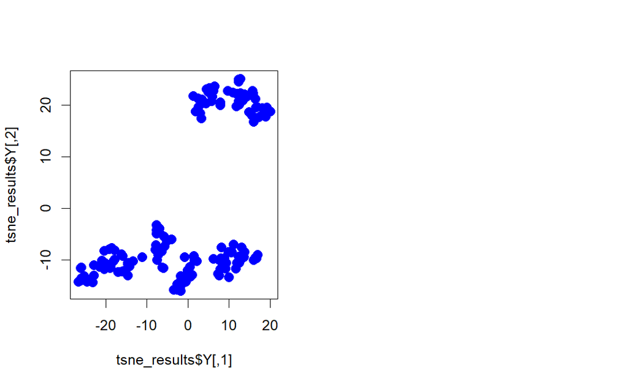

```r
## Generate the t_SNE plot

par(mfrow=c(1,2))
plot(tsne_results$Y, col = "blue", pch = 19, cex = 1.5) # Plotting the first image
plot(tsne_results$Y, col = "black", bg= iris_species, pch = 21, cex = 1.5) # Second plot: Color the plot by the real species type (bg= iris_species)
```

[output not shown]

# multidimensional view (scatterplot-matrix)

Let’s compare the t-sne plot results with what we would obtain through PCA

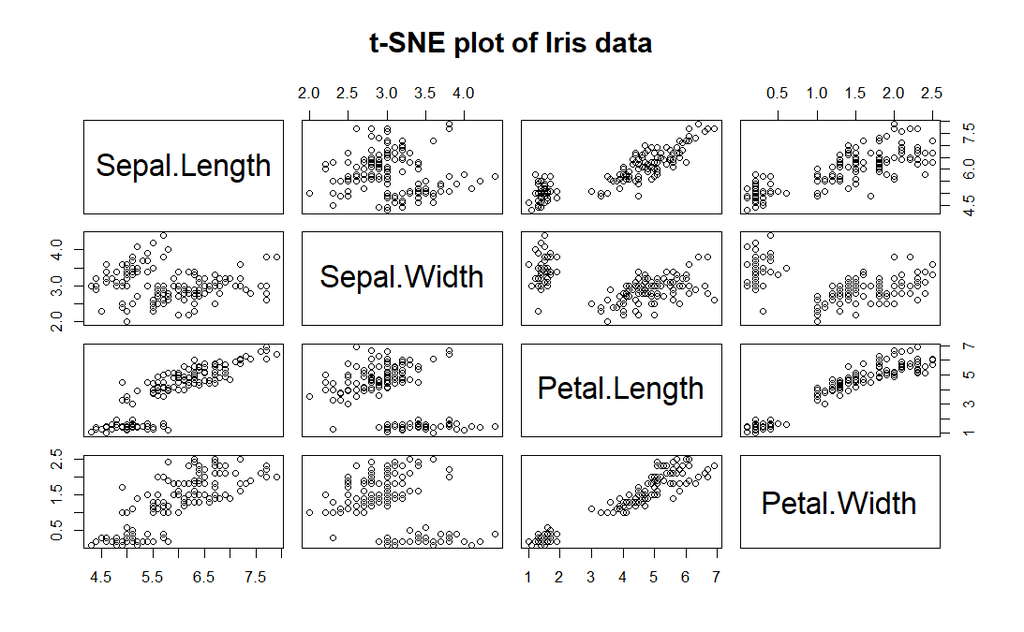

```r
plot(iris_data, col='black', bg=iris_species, main = 't-SNE plot of Iris data')


par(mfrow=c(1,2))
```

```r
# PCA
pca_iris = princomp(iris_data, scores = T)$scores[,1:2]
plot(pca_iris, col = "black", bg=iris_species, pch = 21, cex = 1.5, main = 'PCA plot of Iris data')
# t-SNE
plot(tsne_results$Y, col = "black", bg=iris_species, pch = 21, cex = 1.5, main = 't-SNE plot of Iris data')
```

[figure not shown]

```r
# We cannot see a huge difference, since the dataset is low-dimensional and its clusters can be quite easily separated through linear methods.


# Just to grasp an intuition of how this algorithm works, let's have a look at what happens if we change the perplexity parameter.
# Again, if you do this experiment on much larger and complex datasets you will see much more significant differences between the plots.
perplex = c(1, 5, 10, 20, 30)

par(mfrow=c(1,5))
```

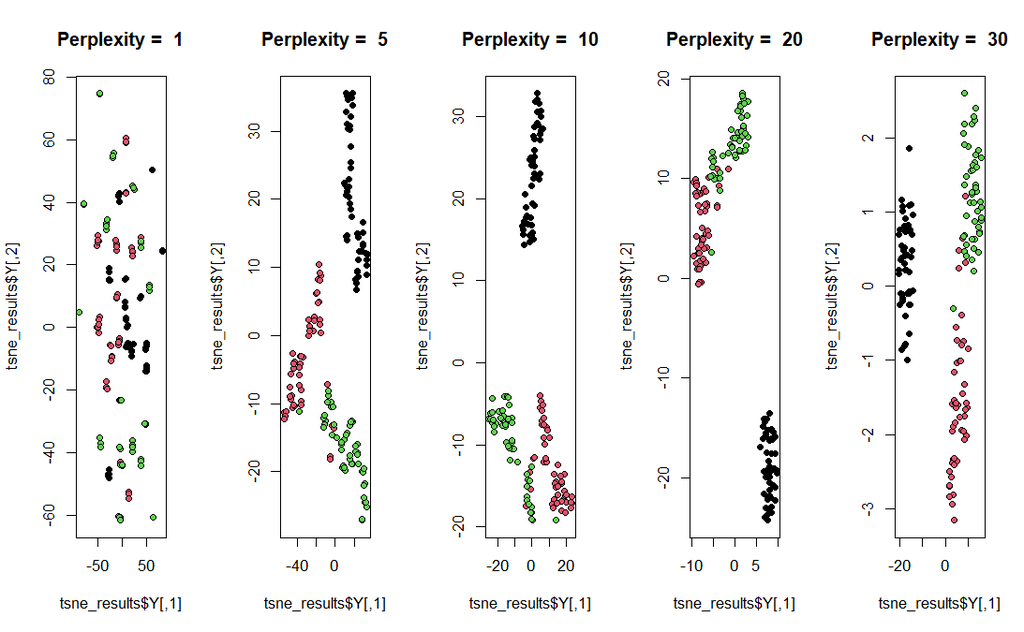

```r
for(k in c(1:5)){

  tsne_results <- Rtsne(iris_data, perplexity=perplex[k], check_duplicates = FALSE, pca=FALSE)
  title = paste("Perplexity = ", perplex[k])
  plot(tsne_results$Y, col = "black", bg= iris_species, pch = 21, cex = 1, main = title)

}
```

#### t-SNE with high-dimensional real genomic data

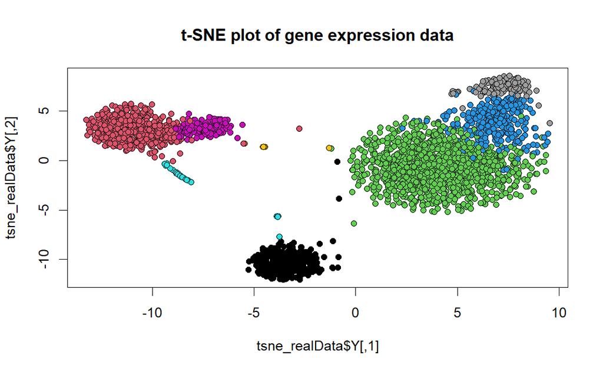

```r
# This is an example of representing datasets with extremely high dimensionality.
# We are dealing with gene expression in single-cell RNA sequencing.
# The data is fake, but formatted as in real-life biology research.
# We will upload two files, the first "Expression File" contain cells in rows and genes in columns,
# the values represent the expression level of each gene.
# You can discriminate cell type according to the expression levels of some genes.

# This is a classical example of fully unsupervised analysis, since you do not know the cell types,
# and you are trying to cluster similar points to infer them.
# I already did "the exercise" for you, and you can find the real cell-type names for each sample
# in the "Meta-data file", so that we can color t-SNE representations.


expression_data <- read.table(file = "expression.csv", row.names = 1, sep=',', header = T)
meta_data <- read.table(file = "meta.csv", row.names = 1, sep=',', header = T)

View(expression_data)

cell_type = as.factor(meta_data$cell_type)

# since t-SNE is an iterative algorithm it may take some time to run for very large datasets.
# For this reason, many times for visualization purposes it is recommended to run PCA first.
# The function in R has the pre-built option to perform PCA first, so now we will set this parameter to true

## Run the t-SNE algorithm
tsne_realData <- Rtsne(expression_data, perplexity=100, check_duplicates = FALSE, pca=TRUE)
## Generate the t_SNE plot

plot(tsne_realData$Y, col = "black", bg= cell_type, pch = 21, cex = 1, main = 't-SNE plot of gene expression data')

# Let's compare our results with pca analysis alone. You will see the algorithm takes the PCA inputs and "separates" the points more
# to aid visualization. For example, now we can recognize the light-blue cluster that was scattered in the middle of the PCA plot.

par(mfrow=c(1,2))
```

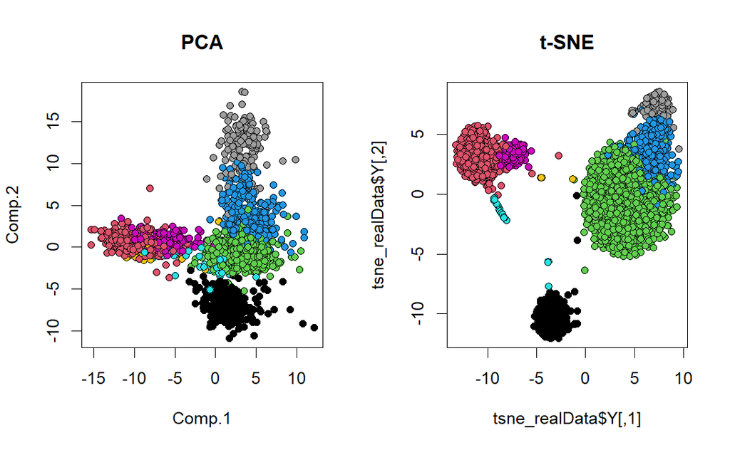

```r
# PCA
pca_genes = princomp(expression_data, scores = T)$scores[,1:2]
plot(pca_genes, col = "black", bg=cell_type, pch = 21, cex = 1, main = 'PCA')
plot(tsne_realData$Y, col = "black", bg= cell_type, pch = 21, cex = 1, main = 't-SNE')
```

The dataset describes n = 1797 digits from 0 to 9 (K = 10), handwritten by 13 subjects. Raw observations are 32x32 bitmaps, which are divided into nonoverlapping blocks of 4x4 and the number of on pixels are counted in each block. This generates p = 64 (= 8x8) variable, recording the normalized counts of pixels in each block and each element is an integer in the range 0 to 16. The row names of the matrix optd contains the true labels (between 0 and 9), and the column names of it contains the position of the block in original bitmap.

FINAL REMARKS

Consider t-SNE as a dimensionality reduction tool mostly meant for VISUALIZATION purposes. Because of the nature of the algorithm, we suggest you not to use it for inference or data transformation.